# Rapport de Contrôle de Qualité ELISA

MOL (laboratoire mobile d´investigation des alertes épidémiques)

11 February 2021

### **Résumé**

Ce rapport résume l´évaluation du contrôle de qualité de la série de plaque ELISA pour le kit **EUROIMMUN Rougeole (IgM - NP)** effectuée à **2020-11-09 14:20:00** par l´operateur **Amy Mikhail**.

Trois standards ont étaient choisi pour évaluer le qualité des résultats:

1. Performance des contrôles internes fourni avec les kits par rapport au limites recommandé du fabricateur pour le lot;
2. Performance des contrôles externes par rapport à la fourchette de valeurs obtenus dans les séries fait au laboratoire de référence;
3. Degré de variation entre les résultats obtenus pour les contrôles doublés dans les positions différentes sur la plaque.

Les critères suivantes ont étaient évaluées:

- Valeurs des témoins internes du kit **entre les limites définis pour cette lot**
- Valeurs des témoins externes **entre 2 écartes types** par rapport au valeurs de référence
- Coefficients de variation entre les puits pour les témoins doublés **moins de 10%**

### **Sommaire de l´évaluation de qualité**

Un tableau récapitulatif des résultats et intérpretations pour les témoins internes et externes est présenté ci-dessous:

[output not shown]

### **Visualisation du performance des témoins externes**

Les graphiques “Levey-Jennings” pour les témoins externes (positif et négatif) sont présenté ci-dessous. Une limite de 2 écartes types (plus ou moins) par rapport au des valeurs de référence (obtenu par le laboratoire de référence dans les conditions optimisées) est défini comme le seuil acceptable. Les valeurs représentés sont des ratios de densités optiques, normalisées par les valeurs du longeur d´onde de référence et le calibreur. Le calibreur du kit EUROIMMUN représente le limite supérieure pour des échantillons qui sont négatif pour les anticorps ciblées.

**A. Graphique Levey-Jenning: témoin externe négatif**

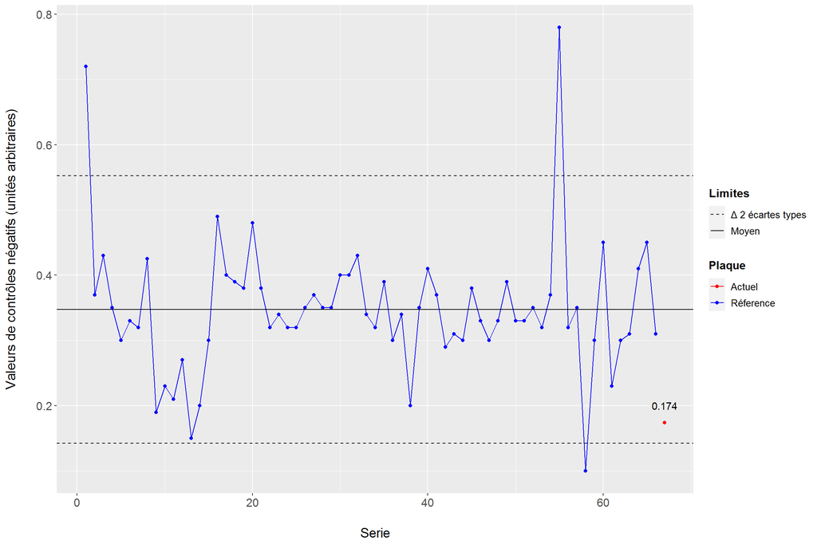

**B. Graphique Levey-Jenning: témoin externe positif**

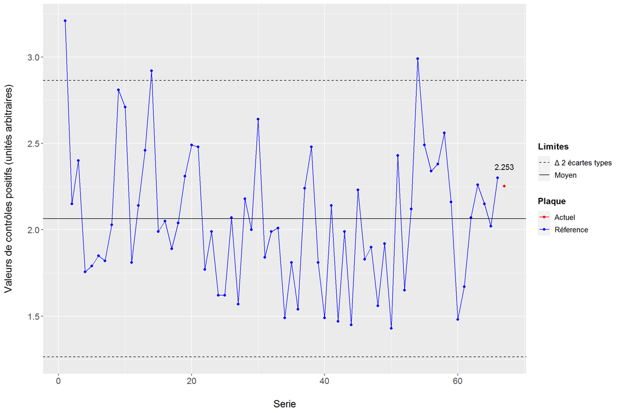

### **Visualisation du plaque**

Les résultats calculés (ratios de Δ DO calibrés) sont représentés dans une forme visuel dans la carte thermique ci-dessous. La carte thermique peut aider à identifier des contaminations croisées, dont les valeurs sont visualisées en fonction de leur position sur la plaque.

**C. Carte thermique des résultats du plaque ELISA**

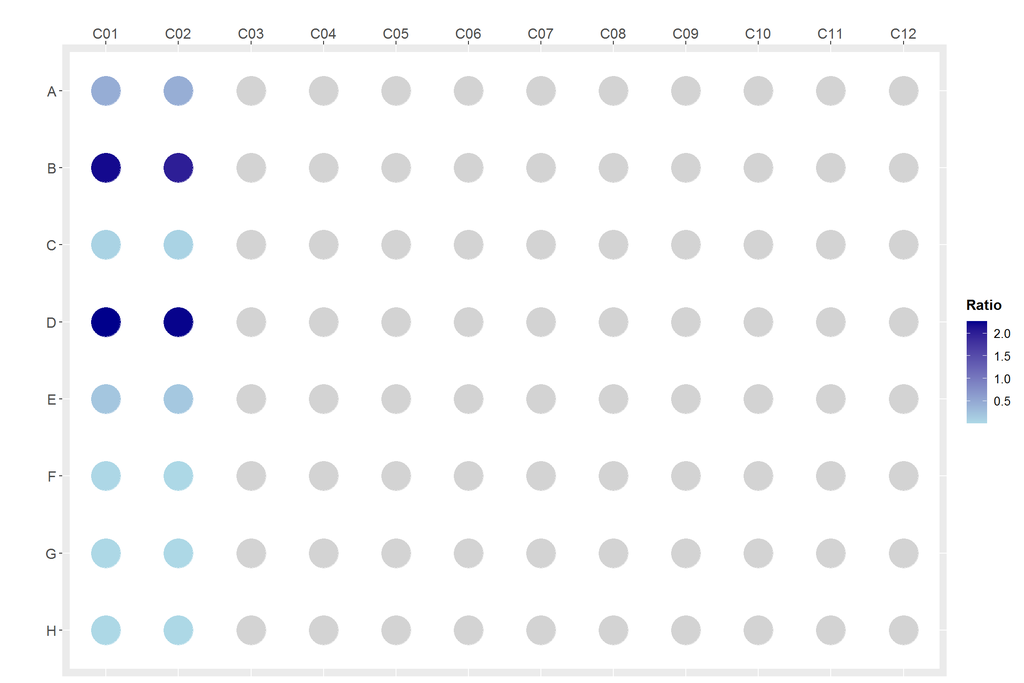

### **Déclaration des résultats de controle de qualité**

[figure not shown]

Ce plaque ELISA a **réussi** de passer les critères de contrôle de la qualité.

Les résultats sont prêts à être communiqués.